# Project done using Google Colab

# Part A

## 1. Data Understanding

### A. Read all the 3 CSV files as DataFrame and store them into 3 separate variables.

```python
# lets import appropriate libraries first
import pandas as pd
import numpy as np
import seaborn as sns
import matplotlib.pyplot as plt
%matplotlib inline
```

```python
# Importing and reading 3 csv files
from google.colab import drive
drive.mount ('/content/drive')
```

```python
dfs= pd.read_csv('/content/drive/MyDrive/python/CSV/Type_S.csv')
dfh= pd.read_csv('/content/drive/MyDrive/python/CSV/Type_H.csv')
dfn= pd.read_csv('/content/drive/MyDrive/python/CSV/Normal.csv')
```

```python
dfs.head()
```

|  | P_incidence | P_tilt | L_angle | S_slope | P_radius | S_Degree | Class |
| --- | --- | --- | --- | --- | --- | --- | --- |
| 0 | 74.377678 | 32.053104 | 78.772013 | 42.324573 | 143.560690 | 56.125906 | Type_S |
| 1 | 89.680567 | 32.704435 | 83.130732 | 56.976132 | 129.955476 | 92.027277 | Type_S |
| 2 | 44.529051 | 9.433234 | 52.000000 | 35.095817 | 134.711772 | 29.106575 | Type_S |
| 3 | 77.690577 | 21.380645 | 64.429442 | 56.309932 | 114.818751 | 26.931841 | Type_S |
| 4 | 76.147212 | 21.936186 | 82.961502 | 54.211027 | 123.932010 | 10.431972 | Type_S |

```python
dfh.head()
```

|  | P_incidence | P_tilt | L_angle | S_slope | P_radius | S_Degree | Class |
| --- | --- | --- | --- | --- | --- | --- | --- |
| 0 | 63.027817 | 22.552586 | 39.609117 | 40.475232 | 98.672917 | -0.254400 | Type_H |
| 1 | 39.056951 | 10.060991 | 25.015378 | 28.995960 | 114.405425 | 4.564259 | Type_H |
| 2 | 68.832021 | 22.218482 | 50.092194 | 46.613539 | 105.985135 | -3.530317 | Type_H |
| 3 | 69.297008 | 24.652878 | 44.311238 | 44.644130 | 101.868495 | 11.211523 | Type_H |
| 4 | 49.712859 | 9.652075 | 28.317406 | 40.060784 | 108.168725 | 7.918501 | Type_H |

```python
dfn.head()
```

|  | P_incidence | P_tilt | L_angle | S_slope | P_radius | S_Degree | Class |
| --- | --- | --- | --- | --- | --- | --- | --- |
| 0 | 38.505273 | 16.964297 | 35.112814 | 21.540976 | 127.632875 | 7.986683 | Normal |
| 1 | 54.920858 | 18.968430 | 51.601455 | 35.952428 | 125.846646 | 2.001642 | Normal |
| 2 | 44.362490 | 8.945435 | 46.902096 | 35.417055 | 129.220682 | 4.994195 | Normal |
| 3 | 48.318931 | 17.452121 | 48.000000 | 30.866809 | 128.980308 | -0.910941 | Normal |
| 4 | 45.701789 | 10.659859 | 42.577846 | 35.041929 | 130.178314 | -3.388910 | Normal |

### B. Print Shape and columns of all the 3 DataFrames

```python
print('dfs:')
print('Shape:', dfs.shape)
print('Columns:',dfs.columns)

print('dfh:')
print('Shape:', dfh.shape)
print('Columns:',dfh.columns)

print('dfn:')
print('Shape:', dfn.shape)
print('Columns:',dfn.columns)
```

```
dfs:
Shape: (150, 7)
Columns: Index(['P_incidence', 'P_tilt', 'L_angle', 'S_slope', 'P_radius', 'S_Degree',
       'Class'],
      dtype='object')
dfh:
Shape: (60, 7)
Columns: Index(['P_incidence', 'P_tilt', 'L_angle', 'S_slope', 'P_radius', 'S_Degree',
       'Class'],
      dtype='object')
dfn:
Shape: (100, 7)
Columns: Index(['P_incidence', 'P_tilt', 'L_angle', 'S_slope', 'P_radius', 'S_Degree',
       'Class'],
      dtype='object')
```

### C. Compare Column names of all the 3 DataFrames and clearly write observations

```python
# checking if all the three dataframes have same column names
dfs.columns == dfh.columns, dfh.columns == dfn.columns, dfs.columns == dfn.columns
```

```
(array([ True,  True,  True,  True,  True,  True,  True]),
 array([ True,  True,  True,  True,  True,  True,  True]),
 array([ True,  True,  True,  True,  True,  True,  True]))
```

So hear it shows that by comparing all the dataset columns they are a ll identitical and good for merging

### D. Print DataTypes of all the 3 DataFrames.

```python
print('Data Type of dfs:')
print(dfs.info())

print('\n Data Type of dfh:')
print(dfh.info())

print('\n Data Type of dfn:')
print(dfn.info())
```

```
Data Type of dfs:
<class 'pandas.core.frame.DataFrame'>
RangeIndex: 150 entries, 0 to 149
Data columns (total 7 columns):
 #   Column       Non-Null Count  Dtype
---  ------       --------------  -----
 0   P_incidence  150 non-null    float64
 1   P_tilt       150 non-null    float64
 2   L_angle      150 non-null    float64
 3   S_slope      150 non-null    float64
 4   P_radius     150 non-null    float64
 5   S_Degree     150 non-null    float64
 6   Class        150 non-null    object
dtypes: float64(6), object(1)
memory usage: 8.3+ KB
None

 Data Type of dfh:
<class 'pandas.core.frame.DataFrame'>
RangeIndex: 60 entries, 0 to 59
Data columns (total 7 columns):
 #   Column       Non-Null Count  Dtype
---  ------       --------------  -----
 0   P_incidence  60 non-null     float64
 1   P_tilt       60 non-null     float64
 2   L_angle      60 non-null     float64
 3   S_slope      60 non-null     float64
 4   P_radius     60 non-null     float64
 5   S_Degree     60 non-null     float64
 6   Class        60 non-null     object
dtypes: float64(6), object(1)
memory usage: 3.4+ KB
None

 Data Type of dfn:
<class 'pandas.core.frame.DataFrame'>
RangeIndex: 100 entries, 0 to 99
Data columns (total 7 columns):
 #   Column       Non-Null Count  Dtype
---  ------       --------------  -----
 0   P_incidence  100 non-null    float64
 1   P_tilt       100 non-null    float64
 2   L_angle      100 non-null    float64
 3   S_slope      100 non-null    float64
 4   P_radius     100 non-null    float64
 5   S_Degree     100 non-null    float64
 6   Class        100 non-null    object
dtypes: float64(6), object(1)
memory usage: 5.6+ KB
None
```

So here all the three dataframes have proper data types how they are supposed to be, all the numerical values have float 64 as dtype and column such as class which is non numerical has object which good.

### E. Observe and share variation in ‘Class’ feature of all the 3 DaraFrames

```python
print('Variable and Distribution for dfs:', dfs['Class'].value_counts(normalize=True).round(2))
print('\nVariable and Distribution for dfn:', dfn['Class'].value_counts(normalize=True).round(2))
print('\nVariable and Distribution for dfh:', dfh['Class'].value_counts(normalize=True).round(2))
```

```
Variable and Distribution for dfs: Class
Type_S    0.89
tp_s      0.11
Name: proportion, dtype: float64

Variable and Distribution for dfn: Class
Normal    0.73
Nrmal     0.27
Name: proportion, dtype: float64

Variable and Distribution for dfh: Class
Type_H    0.62
type_h    0.38
Name: proportion, dtype: float64
```

Here we can see the data frame 'S' (dfs) has two distribution Type_S and tp_s with 0.89 % and 0.11 % distribution.

Here we can see the data frame 'N' (dfn) has two distribution Normal and Nrmal with 0.73 % and 0.27 % distribution.

## 2. Data Preparation and Exploration:

### A. Unify all the variations in ‘Class’ feature for all the 3 DataFrames.

```python
# replacing tp_s, Type_S with type_s and same for the other data frames

dfs['Class'].replace(['tp_s', 'Type_S'], 'type_s', inplace=True)
dfh['Class'].replace(['Type_H'], 'type_h', inplace=True)
dfn['Class'].replace(['Normal', 'Nrmal'], 'type_n', inplace=True)
```

```python
print('Unique Value: ',dfs['Class'].unique())

print('\nUnique Value: ',dfh['Class'].unique())

print('\nUnique Value: ',dfn['Class'].unique())
```

```
Unique Value:  ['type_s']

Unique Value:  ['type_h']

Unique Value:  ['type_n']
```

### B. Combine all the 3 DataFrames to form a single DataFrame

```python
data = pd.concat([dfs, dfh, dfn], axis=0) #concatenating all three data frames
```

```python
data.head()
```

|  | P_incidence | P_tilt | L_angle | S_slope | P_radius | S_Degree | Class |
| --- | --- | --- | --- | --- | --- | --- | --- |
| 0 | 74.377678 | 32.053104 | 78.772013 | 42.324573 | 143.560690 | 56.125906 | type_s |
| 1 | 89.680567 | 32.704435 | 83.130732 | 56.976132 | 129.955476 | 92.027277 | type_s |
| 2 | 44.529051 | 9.433234 | 52.000000 | 35.095817 | 134.711772 | 29.106575 | type_s |
| 3 | 77.690577 | 21.380645 | 64.429442 | 56.309932 | 114.818751 | 26.931841 | type_s |
| 4 | 76.147212 | 21.936186 | 82.961502 | 54.211027 | 123.932010 | 10.431972 | type_s |

```python
data.tail()
```

|  | P_incidence | P_tilt | L_angle | S_slope | P_radius | S_Degree | Class |
| --- | --- | --- | --- | --- | --- | --- | --- |
| 95 | 47.903565 | 13.616688 | 36.000000 | 34.286877 | 117.449062 | -4.245395 | type_n |
| 96 | 53.936748 | 20.721496 | 29.220534 | 33.215251 | 114.365845 | -0.421010 | type_n |
| 97 | 61.446597 | 22.694968 | 46.170347 | 38.751628 | 125.670725 | -2.707880 | type_n |
| 98 | 45.252792 | 8.693157 | 41.583126 | 36.559635 | 118.545842 | 0.214750 | type_n |
| 99 | 33.841641 | 5.073991 | 36.641233 | 28.767649 | 123.945244 | -0.199249 | type_n |

```python
data.shape
```

```
(310, 7)
```

```python
data['Class'].value_counts()
```

```
Class
type_s    150
type_n    100
type_h     60
Name: count, dtype: int64
```

### C. Print 5 random samples of this DataFrame

```python
print(data.sample(5))
```

```
     P_incidence     P_tilt    L_angle    S_slope    P_radius    S_Degree  \
2      68.832021  22.218482  50.092194  46.613539  105.985135   -3.530317
56     46.374088  10.215902  42.700000  36.158185  121.247657   -0.542022
62     80.074914  48.069531  52.403439  32.005383  110.709912   67.727316
29     66.879211  24.891999  49.278597  41.987212  113.477018   -2.005892
145    80.111572  33.942432  85.101608  46.169139  125.593624  100.292107

      Class
2    type_h
56   type_n
62   type_s
29   type_h
145  type_s
```

### D. Print Feature-wise percentage of Null values.

```python
data.isnull().sum()
```

```
P_incidence    0
P_tilt         0
L_angle        0
S_slope        0
P_radius       0
S_Degree       0
Class          0
dtype: int64
```

```python
null_values_percent = data.isnull().sum() * 100/len(data) # multiplying with 100 for percentage and dividing by the total lenth of the rows
print(null_values_percent)
```

```
P_incidence    0.0
P_tilt         0.0
L_angle        0.0
S_slope        0.0
P_radius       0.0
S_Degree       0.0
Class          0.0
dtype: float64
```

### E. Check 5-point summary of the new DataFrame.

```python
data.describe().T
```

|  | count | mean | std | min | 25% | 50% | 75% | max |
| --- | --- | --- | --- | --- | --- | --- | --- | --- |
| P_incidence | 310.0 | 60.496653 | 17.236520 | 26.147921 | 46.430294 | 58.691038 | 72.877696 | 129.834041 |
| P_tilt | 310.0 | 17.542822 | 10.008330 | -6.554948 | 10.667069 | 16.357689 | 22.120395 | 49.431864 |
| L_angle | 310.0 | 51.930930 | 18.554064 | 14.000000 | 37.000000 | 49.562398 | 63.000000 | 125.742385 |
| S_slope | 310.0 | 42.953831 | 13.423102 | 13.366931 | 33.347122 | 42.404912 | 52.695888 | 121.429566 |
| P_radius | 310.0 | 117.920655 | 13.317377 | 70.082575 | 110.709196 | 118.268178 | 125.467674 | 163.071041 |
| S_Degree | 310.0 | 26.296694 | 37.559027 | -11.058179 | 1.603727 | 11.767934 | 41.287352 | 418.543082 |

## 3. Data Analysis

### A. Visualize a heatmap to understand correlation between all features

```python
data.info()
```

```
<class 'pandas.core.frame.DataFrame'>
Index: 310 entries, 0 to 99
Data columns (total 7 columns):
 #   Column       Non-Null Count  Dtype
---  ------       --------------  -----
 0   P_incidence  310 non-null    float64
 1   P_tilt       310 non-null    float64
 2   L_angle      310 non-null    float64
 3   S_slope      310 non-null    float64
 4   P_radius     310 non-null    float64
 5   S_Degree     310 non-null    float64
 6   Class        310 non-null    object
dtypes: float64(6), object(1)
memory usage: 19.4+ KB
```

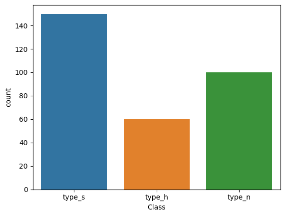

```python
sns.countplot(data, x='Class', hue='Class')
```

```python
corr_num = data[['P_incidence', 'P_tilt', 'L_angle', 'S_slope', 'P_radius', 'S_Degree']]  #Since we only need the numerical clumns for correlation

corr = corr_num.corr()
```

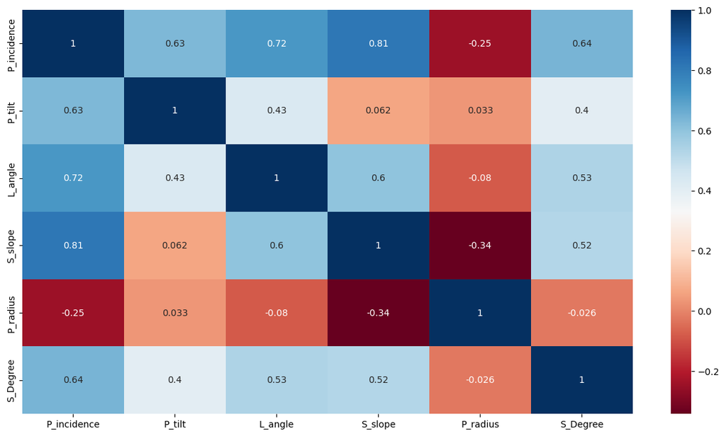

```python
# plotting heat map
plt.figure(figsize=(15,8))
sns.heatmap(corr, annot=True, cmap='RdBu')
```

### B. Share insights on correlation.

A. Feature which have high correlation is between P_incidence and S_slope

### C. Visualize a pairplot with 3 classes distinguished by colors and share insights

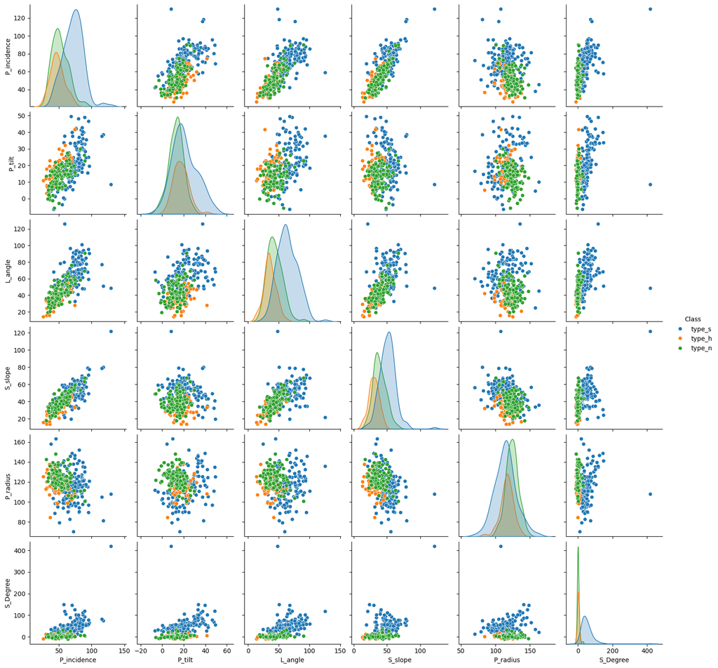

```python
sns.pairplot(data, hue='Class')
```

### D. Visualize a jointplot for ‘P_incidence’ and ‘S_slope’ and share insights.

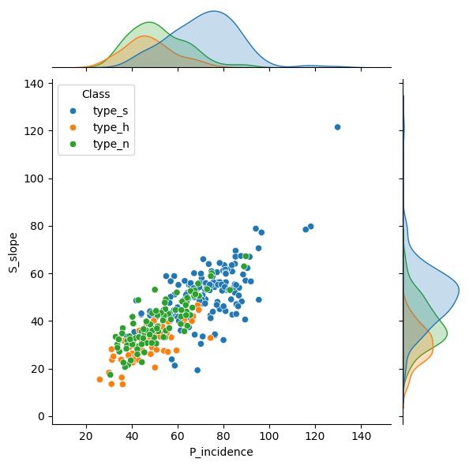

```python
plt.figure(figsize=(10,6))
sns.jointplot(data, x='P_incidence', y='S_slope', hue = 'Class')
```

The jointplot visualizes the relationship between 'P_incidence' and 'S_slope' through a scatter plot in the center and histograms along the axes. We can observe the distribution of both variables along the respective axes. These Variables have a positive correlation between them.

### E. Visualize a boxplot to check distribution of the features and share insights.

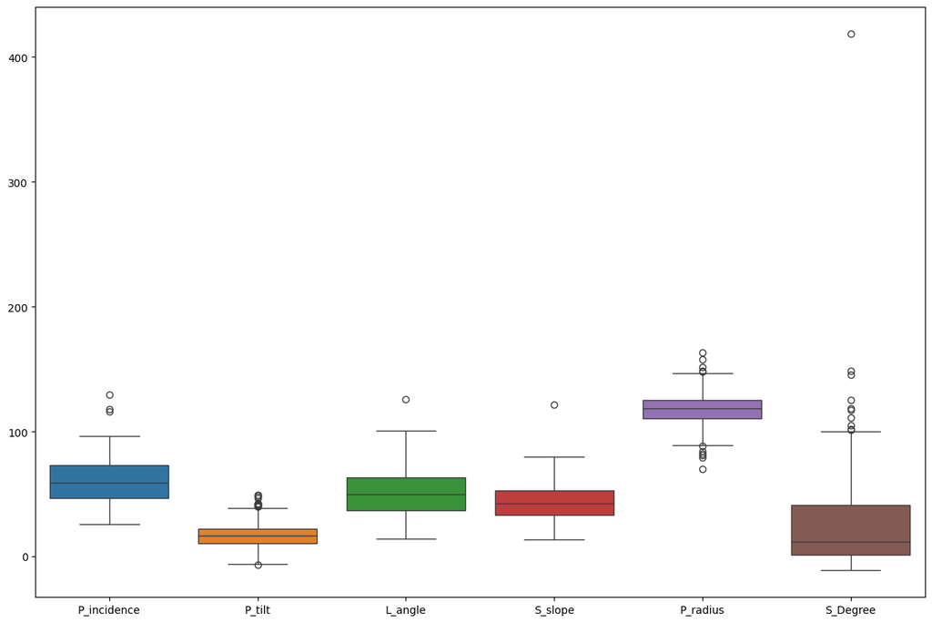

```python
plt.figure(figsize=(15,10))
sns.boxplot(data)
```

Here we see that almost all of them have outliers. S_Degree seems to be having more number if outliers. Each of them have different medians. L_angle and S_slope have median almost similar. The of this both starts at almost the same value but the Q3 ends at different value. Both of them have a outlier.

## 4. Model Building

### A. Split data into X and Y.

### B. Split data into train and test with 80:20 proportion.

```python
from sklearn.model_selection import train_test_split

X = data.drop('Class', axis=1) #predicted features columns
Y = data['Class']

X_train, X_test, Y_train, Y_test = train_test_split(X,Y, test_size = 0.2, random_state = 1) # 1 is just the any random number seed

X_train.head()
```

|  | P_incidence | P_tilt | L_angle | S_slope | P_radius | S_Degree |
| --- | --- | --- | --- | --- | --- | --- |
| 97 | 61.446597 | 22.694968 | 46.170347 | 38.751628 | 125.670725 | -2.707880 |
| 0 | 74.377678 | 32.053104 | 78.772013 | 42.324573 | 143.560690 | 56.125906 |
| 132 | 74.469082 | 33.283157 | 66.942101 | 41.185925 | 146.466001 | 124.984406 |
| 58 | 43.203185 | 19.663146 | 35.000000 | 23.540039 | 124.846109 | -2.919076 |
| 62 | 80.074914 | 48.069531 | 52.403439 | 32.005383 | 110.709912 | 67.727316 |

```python
Y_test.value_counts()
```

```
Class
type_s    28
type_n    20
type_h    14
Name: count, dtype: int64
```

### C. Train a Supervised Learning Classification base model using KNN classifier.

```python
from sklearn.neighbors import KNeighborsClassifier
from sklearn.metrics import accuracy_score, precision_score, recall_score, f1_score, confusion_matrix, classification_report
```

```python
# Builing KNN Model
NNH = KNeighborsClassifier(n_neighbors=5, weights='distance')
NNH.fit (X_train, Y_train)
```

```
KNeighborsClassifier(weights='distance')
```

### D. Print all the possible performance metrics for both train and test data.

```python
print('Train Accuracy: {}'.format(NNH.score(X_train, Y_train)))
pred = NNH.predict(X_test)
print('Test Accuracy: {}'.format(NNH.score(X_test, Y_test)))
```

```
Train Accuracy: 1.0
Test Accuracy: 0.7419354838709677
```

```python
print(classification_report(Y_test, pred))
```

```
              precision    recall  f1-score   support

      type_h       0.56      0.36      0.43        14
      type_n       0.58      0.75      0.65        20
      type_s       0.96      0.93      0.95        28

    accuracy                           0.74        62
   macro avg       0.70      0.68      0.68        62
weighted avg       0.75      0.74      0.74        62
```

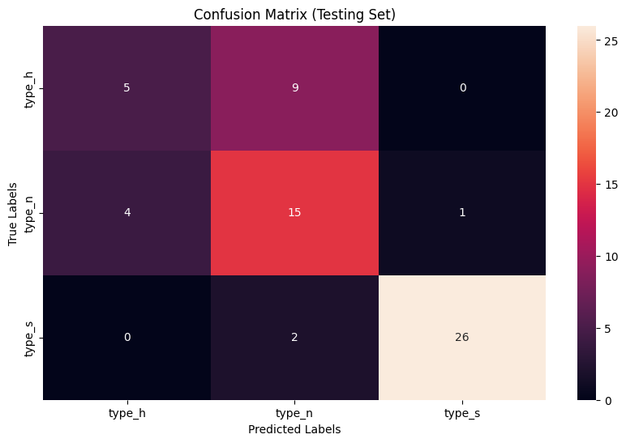

```python
from sklearn.metrics import confusion_matrix
from sklearn import metrics
# Converting Y_test to a pandas Series
Y_test_series = pd.Series(Y_test)

# Getting unique labels from true labels
unique_labels = sorted(Y_test_series.unique())

# Computing Confusion Matrix
cm = metrics.confusion_matrix(Y_test_series, pred, labels=unique_labels)
df_cm = pd.DataFrame(cm, index=unique_labels, columns=unique_labels)

# Visualizizg Confusion Matrix
plt.figure(figsize=(10,6))
sns.heatmap(df_cm, annot=True, fmt='g')
plt.xlabel('Predicted Labels')
plt.ylabel('True Labels')
plt.title('Confusion Matrix (Testing Set)')
```

## 5. Performance Improvement

### A. Experiment with various parameters to improve performance of the base model.

```python
# lets try checking different parameters to check performance
KNeighborsClassifier().get_params()
```

```
{'algorithm': 'auto',
 'leaf_size': 30,
 'metric': 'minkowski',
 'metric_params': None,
 'n_jobs': None,
 'n_neighbors': 5,
 'p': 2,
 'weights': 'uniform'}
```

```python
param_grid = {'n_neighbors': range(1, 20),'weights': ['uniform','distance'],'p': [1, 2]}

knn = KNeighborsClassifier()

random_search = RandomizedSearchCV(knn, param_distributions=param_grid, n_iter=20, scoring='accuracy', cv=5, random_state=42)

random_search.fit(X_train, Y_train)

results = random_search.cv_results_

best_params = random_search.best_params_
best_score = random_search.best_score_

print("Best Hyperparameters:", best_params)
print("Best Accuracy Score:", best_score)
```

```
Best Hyperparameters: {'weights': 'distance', 'p': 2, 'n_neighbors': 9}
Best Accuracy Score: 0.8668571428571429
```

```python
print('Optimal K value for KNN')
print(k_value)
```

[output not shown]

```
Optimal K value for KNN
    K_value  acc_score       MSE    weight  p
14        4   0.806452  0.193548  distance  1
58       15   0.806452  0.193548  distance  1
60       16   0.806452  0.193548   uniform  1
62       16   0.806452  0.193548  distance  1
68       18   0.806452  0.193548   uniform  1
```

looks like 4,15,16 and 18 are suppose to be optimal k values for our KNN classifier

```python
NNH = KNeighborsClassifier(n_neighbors=16, weights='uniform', p=1)
NNH.fit(X_train,Y_train)
```

```
KNeighborsClassifier(n_neighbors=16, p=1)
```

```python
pred=NNH.predict(X_test)
print('Training accuracy: {}'.format(NNH.score(X_train,Y_train)))
print('Test accuracy: {}'.format(NNH.score(X_test,Y_test)))

print('Accuracy score: {}'.format(accuracy_score(Y_test,pred)))
print(classification_report(Y_test,pred))
```

```
Training accuracy: 0.875
Test accuracy: 0.8064516129032258
Accuracy score: 0.8064516129032258
              precision    recall  f1-score   support

      type_h       0.70      0.50      0.58        14
      type_n       0.65      0.85      0.74        20
      type_s       1.00      0.93      0.96        28

    accuracy                           0.81        62
   macro avg       0.78      0.76      0.76        62
weighted avg       0.82      0.81      0.81        62
```

Observations: K_neighbour with 16 neighbours looks to be optimal for required output.

1. We can see a bit of improvement in recall from 0.36 to 0.50 % for type_h
2. Out of 28 our model has identified 26 type_s
3. We can also see approx 15 % of improvement for type h.

# Part B

### 1. Data Understanding and Preparation

#### A. Read both the Datasets ‘Data1’ and ‘Data 2’ as DataFrame and store them into two separate variables.

```python
df1 = pd.read_csv('/content/drive/MyDrive/python/CSV/Data1.csv')
df2 = pd.read_csv('/content/drive/MyDrive/python/CSV/Data2.csv')
```

```python
df1.head()
```

|  | ID | Age | CustomerSince | HighestSpend | ZipCode | HiddenScore | MonthlyAverageSpend | Level |
| --- | --- | --- | --- | --- | --- | --- | --- | --- |
| 0 | 1 | 25 | 1 | 49 | 91107 | 4 | 1.6 | 1 |
| 1 | 2 | 45 | 19 | 34 | 90089 | 3 | 1.5 | 1 |
| 2 | 3 | 39 | 15 | 11 | 94720 | 1 | 1.0 | 1 |
| 3 | 4 | 35 | 9 | 100 | 94112 | 1 | 2.7 | 2 |
| 4 | 5 | 35 | 8 | 45 | 91330 | 4 | 1.0 | 2 |

```python
df2.head()
```

|  | ID | Mortgage | Security | FixedDepositAccount | InternetBanking | CreditCard | LoanOnCard |
| --- | --- | --- | --- | --- | --- | --- | --- |
| 0 | 1 | 0 | 1 | 0 | 0 | 0 | NaN |
| 1 | 2 | 0 | 1 | 0 | 0 | 0 | NaN |
| 2 | 3 | 0 | 0 | 0 | 0 | 0 | NaN |
| 3 | 4 | 0 | 0 | 0 | 0 | 0 | NaN |
| 4 | 5 | 0 | 0 | 0 | 0 | 1 | NaN |

#### B. Print shape and Column Names and DataTypes of both the Dataframes.

```python
print('Data 1: ', df1.shape)
print('Data 2: ', df2.shape)
```

```
Data 1:  (5000, 8)
Data 2:  (5000, 7)
```

```python
print('Data 1 Column names:', df1.columns)
print('\nData 2 Column names:', df2.columns)
```

```
Data 1 Column names: Index(['ID', 'Age', 'CustomerSince', 'HighestSpend', 'ZipCode', 'HiddenScore',
       'MonthlyAverageSpend', 'Level'],
      dtype='object')

Data 2 Column names: Index(['ID', 'Mortgage', 'Security', 'FixedDepositAccount', 'InternetBanking',
       'CreditCard', 'LoanOnCard'],
      dtype='object')
```

#### C. Merge both the Dataframes on ‘ID’ feature to form a single DataFrame

```python
df = pd.merge(df1, df2, how='outer', on = 'ID')
```

```python
df.head()
```

|  | ID | Age | CustomerSince | HighestSpend | ZipCode | HiddenScore | MonthlyAverageSpend | Level | Mortgage | Security | FixedDepositAccount | InternetBanking | CreditCard | LoanOnCard |
| --- | --- | --- | --- | --- | --- | --- | --- | --- | --- | --- | --- | --- | --- | --- |
| 0 | 1 | 25 | 1 | 49 | 91107 | 4 | 1.6 | 1 | 0 | 1 | 0 | 0 | 0 | NaN |
| 1 | 2 | 45 | 19 | 34 | 90089 | 3 | 1.5 | 1 | 0 | 1 | 0 | 0 | 0 | NaN |
| 2 | 3 | 39 | 15 | 11 | 94720 | 1 | 1.0 | 1 | 0 | 0 | 0 | 0 | 0 | NaN |
| 3 | 4 | 35 | 9 | 100 | 94112 | 1 | 2.7 | 2 | 0 | 0 | 0 | 0 | 0 | NaN |
| 4 | 5 | 35 | 8 | 45 | 91330 | 4 | 1.0 | 2 | 0 | 0 | 0 | 0 | 1 | NaN |

#### D. Change Datatype of below features to ‘Object’

```python
# Checking the data types
df.info()
```

```
<class 'pandas.core.frame.DataFrame'>
RangeIndex: 5000 entries, 0 to 4999
Data columns (total 14 columns):
 #   Column               Non-Null Count  Dtype
---  ------               --------------  -----
 0   ID                   5000 non-null   int64
 1   Age                  5000 non-null   int64
 2   CustomerSince        5000 non-null   int64
 3   HighestSpend         5000 non-null   int64
 4   ZipCode              5000 non-null   int64
 5   HiddenScore          5000 non-null   int64
 6   MonthlyAverageSpend  5000 non-null   float64
 7   Level                5000 non-null   int64
 8   Mortgage             5000 non-null   int64
 9   Security             5000 non-null   int64
 10  FixedDepositAccount  5000 non-null   int64
 11  InternetBanking      5000 non-null   int64
 12  CreditCard           5000 non-null   int64
 13  LoanOnCard           4980 non-null   float64
dtypes: float64(2), int64(12)
memory usage: 547.0 KB
```

```python
df = df.astype({'CreditCard':'object', 'InternetBanking':'object', 'FixedDepositAccount':'object', 'Security':'object', 'Level':'object', 'HiddenScore':'object'})
```

```python
df.info()
```

```
<class 'pandas.core.frame.DataFrame'>
RangeIndex: 5000 entries, 0 to 4999
Data columns (total 14 columns):
 #   Column               Non-Null Count  Dtype
---  ------               --------------  -----
 0   ID                   5000 non-null   int64
 1   Age                  5000 non-null   int64
 2   CustomerSince        5000 non-null   int64
 3   HighestSpend         5000 non-null   int64
 4   ZipCode              5000 non-null   int64
 5   HiddenScore          5000 non-null   object
 6   MonthlyAverageSpend  5000 non-null   float64
 7   Level                5000 non-null   object
 8   Mortgage             5000 non-null   int64
 9   Security             5000 non-null   object
 10  FixedDepositAccount  5000 non-null   object
 11  InternetBanking      5000 non-null   object
 12  CreditCard           5000 non-null   object
 13  LoanOnCard           4980 non-null   float64
dtypes: float64(2), int64(6), object(6)
memory usage: 547.0+ KB
```

### 2. Data Exploration and Analysis

#### A. Visualize distribution of Target variable ‘LoanOnCard’ and clearly share insights.

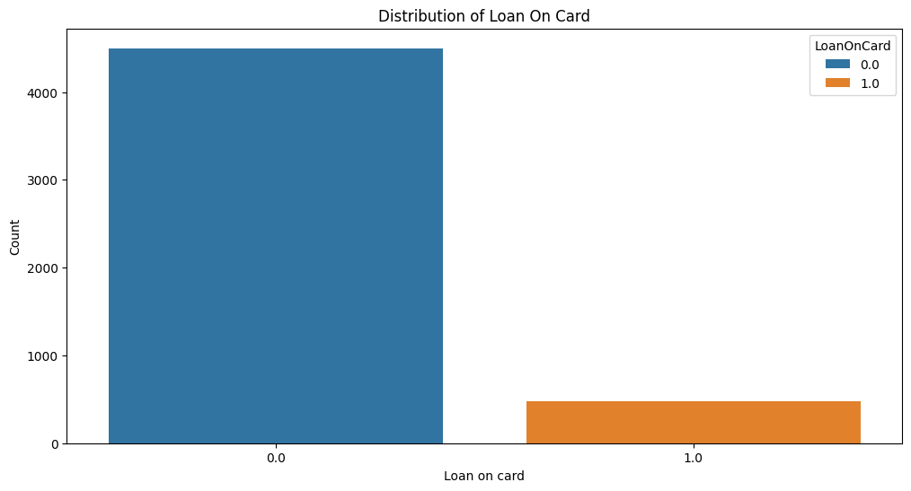

```python
plt.figure(figsize=(12,6))
sns.countplot(df, x='LoanOnCard', hue='LoanOnCard')
plt.title('Distribution of Loan On Card')
plt.xlabel('Loan on card')
plt.ylabel('Count')
```

Looking at the countplot it looks like Loan on card taken by people is much less compared to people not taking loan on card. Data shows people do not like to take loan on cards.

#### B. Check the percentage of missing values and impute if required.

```python
df.isnull().value_counts()
```

```
ID     Age    CustomerSince  HighestSpend  ZipCode  HiddenScore  MonthlyAverageSpend  Level  Mortgage  Security  FixedDepositAccount  InternetBanking  CreditCard  LoanOnCard
False  False  False          False         False    False        False                False  False     False     False                False            False       False         4980
                                                                                                                                                                   True            20
Name: count, dtype: int64
```

```python
df.isnull().sum()/len(df) * 100
```

```
ID                     0.0
Age                    0.0
CustomerSince          0.0
HighestSpend           0.0
ZipCode                0.0
HiddenScore            0.0
MonthlyAverageSpend    0.0
Level                  0.0
Mortgage               0.0
Security               0.0
FixedDepositAccount    0.0
InternetBanking        0.0
CreditCard             0.0
LoanOnCard             0.4
dtype: float64
```

```python
df['LoanOnCard'].unique()
```

```
array([nan,  1.,  0.])
```

```python
Nan = df[df['LoanOnCard'].isnull()]
print('Rows containing NaN values in the LoanOnCard column:')
print(Nan)
```

```
Rows containing NaN values in the LoanOnCard column:
    ID  Age  CustomerSince  HighestSpend  ZipCode HiddenScore  \
0    1   25              1            49    91107           4
1    2   45             19            34    90089           3
2    3   39             15            11    94720           1
3    4   35              9           100    94112           1
4    5   35              8            45    91330           4
5    6   37             13            29    92121           4
6    7   53             27            72    91711           2
7    8   50             24            22    93943           1
8    9   35             10            81    90089           3
79  80   50             26            19    94720           2
80  81   60             36            41    95134           4
81  82   47             22            40    94612           3
82  83   41             16            82    92507           1
```

[output cut: 51 more lines]

```python
# Since there are only 20 values we can impute them with zeros
df['LoanOnCard'].fillna(0, inplace=True)
```

```python
df.head()
```

|  | ID | Age | CustomerSince | HighestSpend | ZipCode | HiddenScore | MonthlyAverageSpend | Level | Mortgage | Security | FixedDepositAccount | InternetBanking | CreditCard | LoanOnCard |
| --- | --- | --- | --- | --- | --- | --- | --- | --- | --- | --- | --- | --- | --- | --- |
| 0 | 1 | 25 | 1 | 49 | 91107 | 4 | 1.6 | 1 | 0 | 1 | 0 | 0 | 0 | 0.0 |
| 1 | 2 | 45 | 19 | 34 | 90089 | 3 | 1.5 | 1 | 0 | 1 | 0 | 0 | 0 | 0.0 |
| 2 | 3 | 39 | 15 | 11 | 94720 | 1 | 1.0 | 1 | 0 | 0 | 0 | 0 | 0 | 0.0 |
| 3 | 4 | 35 | 9 | 100 | 94112 | 1 | 2.7 | 2 | 0 | 0 | 0 | 0 | 0 | 0.0 |
| 4 | 5 | 35 | 8 | 45 | 91330 | 4 | 1.0 | 2 | 0 | 0 | 0 | 0 | 1 | 0.0 |

```python
df['LoanOnCard'].isnull().value_counts()
```

```
LoanOnCard
False    5000
Name: count, dtype: int64
```

```python
df.isnull().value_counts()
```

```
ID     Age    CustomerSince  HighestSpend  ZipCode  HiddenScore  MonthlyAverageSpend  Level  Mortgage  Security  FixedDepositAccount  InternetBanking  CreditCard  LoanOnCard
False  False  False          False         False    False        False                False  False     False     False                False            False       False         5000
Name: count, dtype: int64
```

```python
df['LoanOnCard'].unique()
```

```
array([0., 1.])
```

#### C. Check for unexpected values in each categorical variable and impute them with the best suitable value.

```python
for column in df.columns:
    if df[column].dtype == 'object':
        unique_values = df[column].unique()
        print(f'Column:',column)
        print(f'Unique values:',unique_values)
```

```
Column: HiddenScore
Unique values: [4 3 1 2]
Column: Level
Unique values: [1 2 3]
Column: Security
Unique values: [1 0]
Column: FixedDepositAccount
Unique values: [0 1]
Column: InternetBanking
Unique values: [0 1]
Column: CreditCard
Unique values: [0 1]
```

Looks like there are no unexpected values in the categorical columns

### 3. Data Preparation and model building

#### A. Split data into X and Y.

```python
df.drop(['ID', 'ZipCode'], axis=1, inplace=True) # droping ID and ZipCode
```

```python
X = df.drop('LoanOnCard', axis=1)
y = df['LoanOnCard']
```

```python
X.head()
```

|  | Age | CustomerSince | HighestSpend | HiddenScore | MonthlyAverageSpend | Level | Mortgage | Security | FixedDepositAccount | InternetBanking | CreditCard |
| --- | --- | --- | --- | --- | --- | --- | --- | --- | --- | --- | --- |
| 0 | 25 | 1 | 49 | 4 | 1.6 | 1 | 0 | 1 | 0 | 0 | 0 |
| 1 | 45 | 19 | 34 | 3 | 1.5 | 1 | 0 | 1 | 0 | 0 | 0 |
| 2 | 39 | 15 | 11 | 1 | 1.0 | 1 | 0 | 0 | 0 | 0 | 0 |
| 3 | 35 | 9 | 100 | 1 | 2.7 | 2 | 0 | 0 | 0 | 0 | 0 |
| 4 | 35 | 8 | 45 | 4 | 1.0 | 2 | 0 | 0 | 0 | 0 | 1 |

```python
X.shape
```

```
(5000, 11)
```

```python
y.shape
```

```
(5000,)
```

```python
y.value_counts()
```

```
LoanOnCard
0.0    4520
1.0     480
Name: count, dtype: int64
```

#### B. Split data into train and test. Keep 25% data reserved for testing.

```python
from sklearn.model_selection import train_test_split
```

```python
X_train, X_test, y_train, y_test = train_test_split(X, y, test_size=0.25, random_state=42)
```

```python
print('Shape of X_train:', X_train.shape)
print('Shape of X_test:', X_test.shape)
print('Shape of Y_train:', y_train.shape)
print('Shape of Y_test:', y_test.shape)
```

```
Shape of X_train: (3750, 11)
Shape of X_test: (1250, 11)
Shape of Y_train: (3750,)
Shape of Y_test: (1250,)
```

#### C. Train a Supervised Learning Classification base model - Logistic Regression.

```python
from sklearn.linear_model import LogisticRegression
```

```python
model = LogisticRegression(solver='sag')
model.fit(X_train, y_train)
```

```
LogisticRegression(solver='sag')
```

#### D. Print evaluation metrics for the model and clearly share insights.

```python
from sklearn.metrics import accuracy_score, precision_score, recall_score, f1_score, confusion_matrix
```

```python
y_pred = model.predict(X_test)
```

```python
accuracy = accuracy_score(y_test, y_pred)
precision = precision_score(y_test, y_pred)
recall = recall_score(y_test, y_pred)
f1 = f1_score(y_test, y_pred)
conf_matrix = confusion_matrix(y_test, y_pred)
```

```python
print('Accuracy:', accuracy)
print('Precision:', precision)
print('Recall:', recall)
print('F1-score:', f1)
print('\nConfusion Matrix:')
print(conf_matrix)
```

```
Accuracy: 0.9056
Precision: 0.6290322580645161
Recall: 0.291044776119403
F1-score: 0.39795918367346944

Confusion Matrix:
[[1093   23]
 [  95   39]]
```

#### E. Balance the data using the right balancing technique.

```python
from sklearn.utils import resample
```

```python
y.value_counts(normalize=True) #checking target variable distribution
```

```
LoanOnCard
0.0    0.904
1.0    0.096
Name: proportion, dtype: float64
```

```python
#Separating majority (Class B) and minority (Class A) classes
class_majority = df[y == 0]
class_minority = df[y == 1]
```

```python
class_minority_upsampled = resample(class_minority, replace=True, n_samples=len(class_majority) * 4, random_state=42)  #Upsample to 4 times of majority class
```

```python
df_upsampled = pd.concat([class_majority, class_minority_upsampled])
```

```python
class_majority_undersampled = resample(class_majority, replace=False, n_samples=len(class_minority), random_state=42)
```

```python
#combining majority and minority class
df_balanced = pd.concat([class_majority_undersampled, class_minority])
```

```python
X_balanced = df_balanced.drop('LoanOnCard', axis = 1) #seperating X features
y_balanced = df_balanced['LoanOnCard']
```

```python
#checking balanced target distribution
balanced_target_distribution = y_balanced.value_counts(normalize=True)
print('\nBalalnced Distribution of Target Variable:')
print(balanced_target_distribution)
```

```
Balalnced Distribution of Target Variable:
LoanOnCard
0.0    0.5
1.0    0.5
Name: proportion, dtype: float64
```

#### F. Again train the same previous model on balanced data.

```python
#re-training the model on the balanced data
balanced_model = LogisticRegression(solver='sag')
balanced_model.fit(X_balanced, y_balanced)
```

```
LogisticRegression(solver='sag')
```

```python
balanced_pred = balanced_model.predict(X_test)
```

```python
balanced_accuracy = accuracy_score(y_test, balanced_pred)
balanced_precision = precision_score(y_test, balanced_pred)
balanced_recall = recall_score(y_test, balanced_pred)
balanced_f1 = f1_score(y_test, balanced_pred)
balanced_conf_matrix = confusion_matrix(y_test, balanced_pred)
```

```python
print('Evaluation Metrics on Balanced Data:')
print('Accuracy:', balanced_accuracy)
print('Precision:', balanced_precision)
print('Recall:', balanced_recall)
print('F1-score:', balanced_f1)
print('\nConfusion Matrix:')
print(balanced_conf_matrix)
```

```
Evaluation Metrics on Balanced Data:
Accuracy: 0.8544
Precision: 0.4166666666666667
Recall: 0.8955223880597015
F1-score: 0.5687203791469194

Confusion Matrix:
[[948 168]
 [ 14 120]]
```

### 4. Performance Improvement

#### A. Train a base model each for SVM, KNN.

```python
from sklearn.svm import SVC
from sklearn.neighbors import KNeighborsClassifier
```

```python
svm_model = SVC()
svm_model.fit(X_train, y_train)
```

```
SVC()
```

```python
knn_model = KNeighborsClassifier()
knn_model.fit(X_train, y_train)
```

```
KNeighborsClassifier()
```

```python
from sklearn.metrics import classification_report

svm_base_predictions = svm_model.predict(X_test)
knn_base_predictions = knn_model.predict(X_test)
```

```python
print("Classification Report for SVM Base Model:")
print(classification_report(y_test, svm_base_predictions))

print("\nClassification Report for KNN Base Model:")
print(classification_report(y_test, knn_base_predictions))
```

```
Classification Report for SVM Base Model:
              precision    recall  f1-score   support

         0.0       0.90      1.00      0.95      1116
         1.0       0.69      0.08      0.15       134

    accuracy                           0.90      1250
   macro avg       0.79      0.54      0.55      1250
weighted avg       0.88      0.90      0.86      1250


Classification Report for KNN Base Model:
              precision    recall  f1-score   support

         0.0       0.92      0.97      0.95      1116
         1.0       0.60      0.31      0.41       134

    accuracy                           0.90      1250
   macro avg       0.76      0.64      0.68      1250
weighted avg       0.89      0.90      0.89      1250
```

#### B. Tune parameters for each of the models wherever required and finalize a model.

```python
from scipy.stats import uniform, randint
from sklearn.model_selection import RandomizedSearchCV

# Defining the parameter distributions for KNN
knn_param_dist = {
    'n_neighbors': randint(3, 20),
    'weights': ['uniform', 'distance'],
    'metric': ['euclidean', 'manhattan']}

knn_model = KNeighborsClassifier() # Initializing KNN classifier

# Performing randomized search with cross-validation
knn_random_search = RandomizedSearchCV(knn_model, param_distributions=knn_param_dist, n_iter=20, cv=5, n_jobs=-1)

knn_random_search.fit(X_train, y_train)

best_knn_params = knn_random_search.best_params_

# Finalizing the KNN model with the best parameters
final_knn_model = KNeighborsClassifier(**best_knn_params)
final_knn_model.fit(X_train, y_train)
```

```
KNeighborsClassifier(metric='manhattan', n_neighbors=7)
```

```python
knn_pred = final_knn_model.predict(X_test)

print("Classification Report for final KNN Model:")
print(classification_report(y_test, knn_pred))
```

```
Classification Report for final KNN Model:
              precision    recall  f1-score   support

         0.0       0.93      0.99      0.96      1116
         1.0       0.78      0.34      0.47       134

    accuracy                           0.92      1250
   macro avg       0.85      0.66      0.71      1250
weighted avg       0.91      0.92      0.90      1250
```

1. Precision Improvement: For class 1 (positive class), the precision improved from 0.60 to 0.78. This indicates that the final KNN model is better at correctly identifying positive instances without falsely labeling too many negative instances as positive.
2. Recall Improvement: For class 1 (positive class), the recall improved from 0.31 to 0.34. This indicates that the final KNN model is better at capturing a larger proportion of actual positive instances.
3. F1-Score Improvement: For class 1 (positive class), the F1-score improved from 0.41 to 0.47. This is a harmonic mean of precision and recall and provides a balanced measure of the model's performance.
4. Overall Accuracy Improvement: The overall accuracy of the final KNN model improved from 0.90 to 0.92. This indicates that the final KNN model performs better in correctly classifying both positive and negative instances. 5.Macro and Weighted Average Improvement: Both macro and weighted average metrics for precision, recall, and F1-score also show improvements, indicating a more balanced performance across classes.

In summary, the final KNN model demonstrates improvements in precision, recall, F1-score, and overall accuracy compared to the base KNN model. These improvements suggest that the final KNN model is better at distinguishing between the positive and negative classes and has better overall performance.